# Experiment 2: Pre-registration code

Sean Trott

February 16, 2021

# Load data

```r
### Set working directory (comment this out to run)
# setwd("/Users/seantrott/Dropbox/UCSD/Research/Ambiguity/SSD/trott_polysemy_experiment/src/analysis")

### Load preprocessed data
df_e2 = read_csv("../../data/processed/polysemy_s2_main.csv")
### Filter to trials from main study (including fillers)
df_e2_main = df_e2 %>%
  filter(practice == "main")
nrow(df_e2_main)
```

```
## [1] 53536
```

```r
### critical trials
df_e2_critical = df_e2 %>%
  filter(critical == "yes") %>%
  filter(order == "second") ## Get only "second" trials (should be 56 per ppt)
nrow(df_e2_critical)
```

```
## [1] 13384
```

```r
### first trials (for critical sentences)
df_e2_first = df_e2 %>%
  filter(critical == "yes") %>%
  filter(order == "first") ## Get only "second" trials (should be 56 per ppt)
nrow(df_e2_first)
```

```
## [1] 13384
```

```r
### Info about study
length(unique(df_e2_critical$subject))
```

```
## [1] 239
```

```r
table(df_e2_critical$same, df_e2_critical$ambiguity_type)
```

```
##
##         Homonymy Polysemy
##   FALSE     2580     6457
##   TRUE      1299     3048
```

```r
### Recode version information to omit order, so it can be merged with distance information
df_e2_critical$version = fct_recode(
  df_e2_critical$version_with_order,
  M1_a_M1_b = "M1_b_M1_a",
  M1_b_M2_a = "M2_a_M1_b",
  M1_a_M2_a = "M2_a_M1_a",
  M1_a_M2_b = "M2_b_M1_a",
  M1_b_M2_b = "M2_b_M1_b",
  M2_a_M2_b = "M2_b_M2_a"
)
```

# Preprocessing: Exclusion criteria

## Bot checks

```r
df_ppt_bots = df_e2 %>%
  filter(type == "bot_check") %>%
  mutate(b1_correct = B1 == 2,
         b2_correct = B2 == "Chair")

df_bot_summ = df_ppt_bots %>%
  group_by(subject) %>%
  summarise(bot_avg = (b1_correct + b2_correct) / 2)
df_bot_summ
```

```
## # A tibble: 239 x 2
##    subject    bot_avg
##    <chr>        <dbl>
##  1 025wu2m6bs     1
##  2 02cpp7rcbk     1
##  3 0fjfspy2zq     1
##  4 0jrp4p98ro     1
##  5 0l5gfo1s81     1
##  6 11d329mhsy     0.5
##  7 11pz67y2jv     1
##  8 11s3zyvhm4     1
##  9 14y9ru14du     1
## 10 1lzneddpkq     1
## # … with 229 more rows
```

```r
## Now remove ppts from critical stims that have < 100% avearge
df_e2_critical = df_e2_critical %>%
  left_join(df_bot_summ, by = "subject") %>%
  filter(bot_avg == 1)
length(unique(df_e2_critical$subject))
```

```
## [1] 231
```

## Demographic data

After preprocessing:

```r
df_demo = df_e2_critical %>%
  group_by(subject, Gender, Native_Speaker, Mobile_Device, Age) %>%
  summarise(mean_rt = mean(rt))
table(df_demo$Gender)
```

```
##
##               Female                 Male           Non-binary
##                  160                   62                    2
## Prefer not to answer
##                    7
```

```r
table(df_demo$Native_Speaker)
```

```
##
##                   No Prefer not to answer                  Yes
##                   12                    4                  215
```

```r
table(df_demo$Mobile_Device)
```

```
##
##                   No Prefer not to answer                  Yes
##                  216                    2                   13
```

```r
# For Age calculations only, ignore subject who responded with string
df_demo = df_demo %>%
  filter(Age != "n/a")
df_demo$age = as.numeric(df_demo$Age)

mean(df_demo$age, na.rm = TRUE)
```

```
## [1] 20.329
```

```r
sd(df_demo$age, na.rm = TRUE)
```

```
## [1] 2.086182
```

```r
range(df_demo$age, na.rm = TRUE)
```

```
## [1] 18 32
```

Exclude non-native speakers:

```r
df_e2_critical = df_e2_critical %>%
  filter(Native_Speaker == "Yes")
length(unique(df_e2_critical$subject))
```

```
## [1] 215
```

Exclude people who performed experiment on mobile device:

```r
df_e2_critical = df_e2_critical %>%
  filter(Mobile_Device == "No")
length(unique(df_e2_critical$subject))
```

```
## [1] 200
```

## Remove RTs

First, we remove trials with an RT < 500ms. For convenience, we also log RT here.

```r
df_e2_critical = df_e2_critical %>%
  filter(rt > 500) %>% ## Remove <= 500 ms
  mutate(log_rt = log(rt)) ## Log RT

nrow(df_e2_critical)
```

```
## [1] 10467
```

Second, we remove trials with an RT > 3 SDs above a subject's mean.

```r
df_e2_critical = df_e2_critical %>%
  group_by(subject) %>%
  mutate(rt_z = scale(rt))

df_e2_critical = df_e2_critical %>%
  filter(rt_z < 3)
nrow(df_e2_critical)
```

```
## [1] 10236
```

## Remove subjects with too few observations

Finally, we remove subjects for whom more than half the observations have been removed (for slow or very fast RTs).

```r
HALF = 28

df_e2_critical = df_e2_critical %>%
  group_by(subject) %>%
  mutate(count = n())

df_e2_critical = df_e2_critical %>%
  filter(count > HALF)
nrow(df_e2_critical)
```

```
## [1] 10146
```

```r
length(unique(df_e2_critical$subject))
```

```
## [1] 187
```

# Exclusion criteria to first-trial data

## Bot checks

```r
df_ppt_bots = df_e2 %>%
  filter(type == "bot_check") %>%
  mutate(b1_correct = B1 == 2,
         b2_correct = B2 == "Chair")

df_bot_summ = df_ppt_bots %>%
  group_by(subject) %>%
  summarise(bot_avg = (b1_correct + b2_correct) / 2)
df_bot_summ
```

```
## # A tibble: 239 x 2
##    subject    bot_avg
##    <chr>        <dbl>
##  1 025wu2m6bs     1
##  2 02cpp7rcbk     1
##  3 0fjfspy2zq     1
##  4 0jrp4p98ro     1
##  5 0l5gfo1s81     1
##  6 11d329mhsy     0.5
##  7 11pz67y2jv     1
##  8 11s3zyvhm4     1
##  9 14y9ru14du     1
## 10 1lzneddpkq     1
## # … with 229 more rows
```

```r
## Now remove ppts from critical stims that have < 100% avearge
df_e2_first = df_e2_first %>%
  left_join(df_bot_summ, by = "subject") %>%
  filter(bot_avg == 1)
length(unique(df_e2_first$subject))
```

```
## [1] 231
```

## Exclude non-native speakers and mobile devices

Exclude non-native speakers:

```r
df_e2_first = df_e2_first %>%
  filter(Native_Speaker == "Yes")
length(unique(df_e2_first$subject))
```

```
## [1] 215
```

Exclude people who performed experiment on mobile device:

```r
df_e2_first = df_e2_first %>%
  filter(Mobile_Device == "No")
length(unique(df_e2_first$subject))
```

```
## [1] 200
```

## Remove RTs

First, we remove trials with an RT < 500ms. For convenience, we also log RT here.

```r
df_e2_first = df_e2_first %>%
  filter(rt > 500) %>% ## Remove <= 500 ms
  mutate(log_rt = log(rt)) ## Log RT

nrow(df_e2_first)
```

```
## [1] 10522
```

Second, we remove trials with an RT > 3 SDs above a subject's mean.

```r
df_e2_first = df_e2_first %>%
  group_by(subject) %>%
  mutate(rt_z = scale(rt))

df_e2_first = df_e2_first %>%
  filter(rt_z < 3)
nrow(df_e2_first)
```

```
## [1] 10325
```

## Remove subjects with too few observations

Finally, we remove subjects for whom more than half the observations have been removed (for slow or very fast RTs).

```r
HALF = 28

df_e2_first = df_e2_first %>%
  group_by(subject) %>%
  mutate(count = n())

df_e2_first = df_e2_first %>%
  filter(count > HALF)
nrow(df_e2_first)
```

```
## [1] 10259
```

```r
length(unique(df_e2_first$subject))
```

```
## [1] 188
```

# Calculate and merge with first-trial estimates

First, we calculate first-trial estimates for accuracy and RT:

```r
df_by_item_first = df_e2_first %>%
  group_by(word, item_version) %>%
  summarise(prior_accuracy = mean(correct_response),
            prior_rt = mean(log_rt))
nrow(df_by_item_first)
```

```
## [1] 416
```

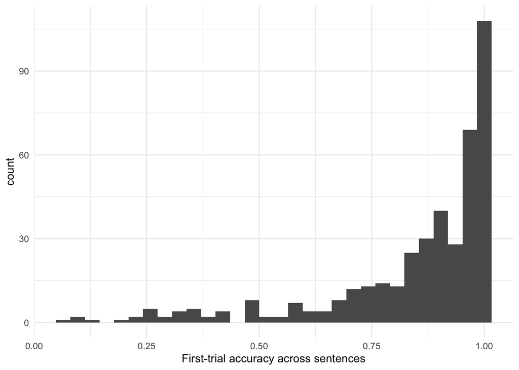

```r
df_by_item_first %>%
  ggplot(aes(x = prior_accuracy)) +
  geom_histogram() +
  labs(x = "First-trial accuracy across sentences") +
  theme_minimal()
```

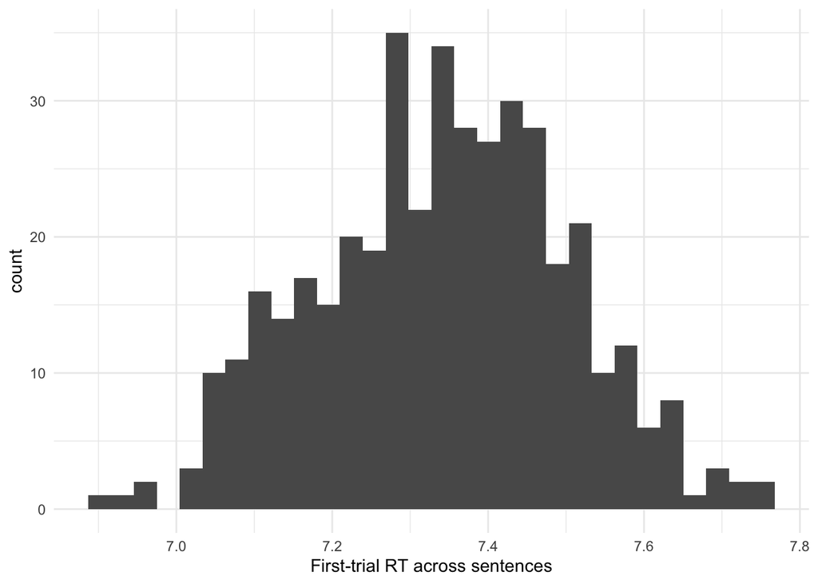

```r
df_by_item_first %>%
  ggplot(aes(x = prior_rt)) +
  geom_histogram() +
  labs(x = "First-trial RT across sentences") +
  theme_minimal()
```

Then, we merge with the critical data:

```r
df_e2_critical_with_priors = df_e2_critical %>%
  left_join(df_by_item_first, on = c("word", "item_version"))
nrow(df_e2_critical)
```

```
## [1] 10146
```

```r
nrow(df_e2_critical_with_priors)
```

```
## [1] 10146
```

# Merge with NLM distances and norming data

Here, we merge the results from the neural language model (NLM) analyses, as well as our norming data.

## Load NLM and norming data

```r
df_distances = read_csv("../../data/processed/stims_processed.csv")
nrow(df_distances)
```

```
## [1] 690
```

```r
df_distances = df_distances %>%
  select(word, version, same, ambiguity_type,
         distance_bert, distance_elmo)

df_normed = read_csv("../../data/stims/item_means.csv")
nrow(df_normed)
```

```
## [1] 672
```

```r
df_normed = df_normed %>%
  select(word, version, same, ambiguity_type, distance_bert, distance_elmo,
         mean_relatedness, median_relatedness, sd_relatedness, se_relatedness, count)


df_item_data = df_normed %>%
  left_join(df_distances, by = c("word", "version",
                                 "same", "ambiguity_type",
                                 "distance_bert", "distance_elmo")) %>%
  mutate(same = factor(same))
nrow(df_item_data)
```

```
## [1] 672
```

```r
table(df_item_data$ambiguity_type, df_item_data$same)
```

```
##
##            FALSE TRUE
##   Homonymy   152   76
##   Polysemy   296  148
```

## Merge with experimental data

```r
df_merged = df_e2_critical_with_priors %>%
  mutate(same = factor(same)) %>%
  left_join(df_item_data, by = c("word", "version",  "same", "ambiguity_type")) %>%
  mutate(length = nchar(word))

nrow(df_e2_critical_with_priors)
```

```
## [1] 10146
```

```r
nrow(df_merged)
```

```
## [1] 10146
```

```r
length(unique(df_merged$subject))
```

```
## [1] 187
```

```r
summary(df_merged$mean_relatedness)
```

```
##    Min. 1st Qu.  Median    Mean 3rd Qu.    Max.
##  0.0000  0.6667  2.1429  2.0784  3.4667  4.0000
```

```r
summary(df_merged$distance_bert)
```

```
##     Min.  1st Qu.   Median     Mean  3rd Qu.     Max.
## 0.009858 0.151840 0.256297 0.269170 0.366402 0.749923
```

```r
# Reorder factor levels
df_merged$ambiguity_type = factor(df_merged$ambiguity_type, levels = c('Polysemy', 'Homonymy'))
df_merged$same = factor(df_merged$same, levels = c(TRUE, FALSE))
```

# Descriptive results

## Accuracy

Let's look at accuracy on the critical trials, broken up by condition. Interestingly, we see that the distribution of accuracy scores on **critical trials** (by participant) is different for `same` vs. `different` sense usages, and lowest still for `different sense` `homonymy`.

```r
df_merged %>%
  group_by(same, ambiguity_type) %>%
  summarise(accuracy = mean(correct_response))
```

```
## # A tibble: 4 x 3
## # Groups:   same [2]
##   same  ambiguity_type accuracy
##   <fct> <fct>             <dbl>
## 1 TRUE  Polysemy          0.924
## 2 TRUE  Homonymy          0.836
## 3 FALSE Polysemy          0.859
## 4 FALSE Homonymy          0.709
```

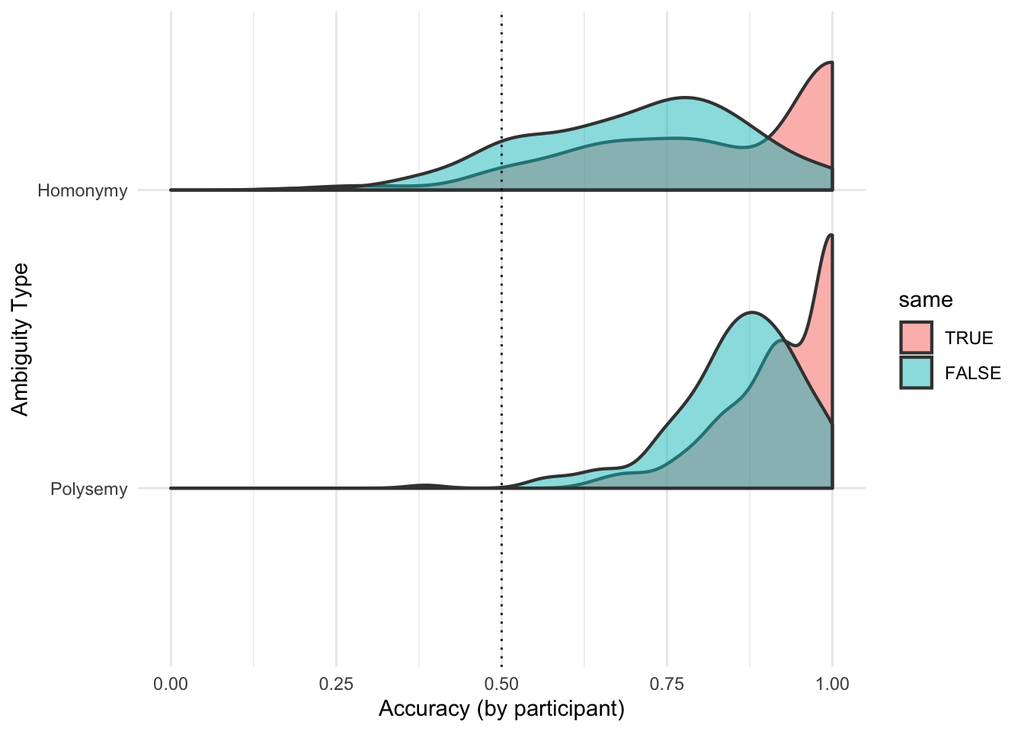

```r
df_merged %>%
  group_by(subject, same, ambiguity_type) %>%
  summarise(accuracy = mean(correct_response)) %>%
  ggplot(aes(x = accuracy,
             y = ambiguity_type,
             fill = same)) +
  geom_density_ridges2(aes(height = ..density..),
                       color=gray(0.25), alpha = 0.5,
                       scale=0.85, size=0.75, stat="density") +
  geom_vline(xintercept = .5, linetype = "dotted") +
  scale_x_continuous(limits = c(0, 1)) +
  labs(x = "Accuracy (by participant)",
       y = "Ambiguity Type",
       color = "Same Sense") +
  theme_minimal()
```

## RT

Now let's look at the `RT` distribution. As expected, RT is right-skewed:

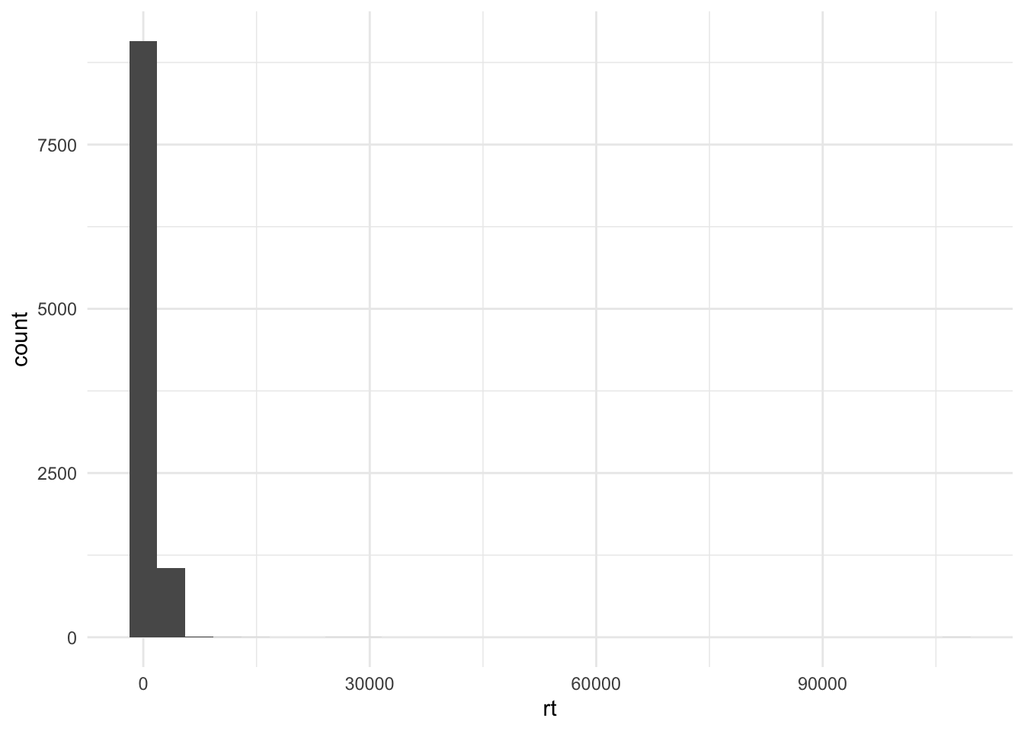

```r
df_merged %>%
  ggplot(aes(x = rt)) +
  geom_histogram() +
  theme_minimal()
```

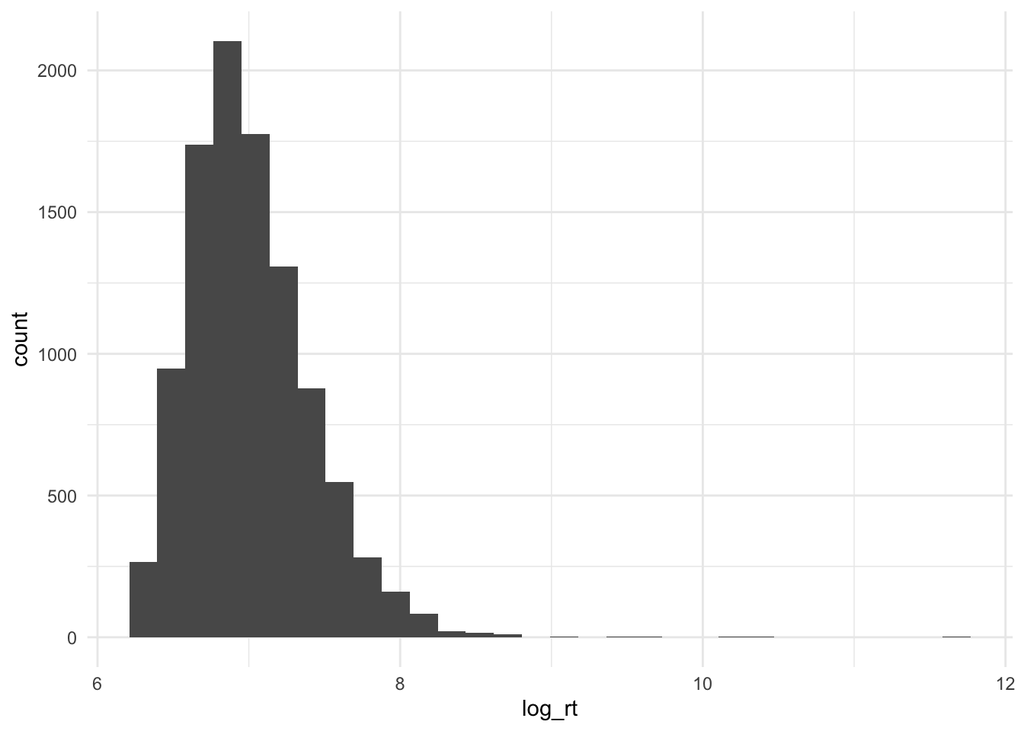

```r
df_merged %>%
  ggplot(aes(x = log_rt)) +
  geom_histogram() +
  theme_minimal()
```

```r
df_merged %>%
  group_by(same) %>%
  summarise(mean_rt = mean(rt),
            mean_log_rt = mean(log_rt))
```

```
## # A tibble: 2 x 3
##   same  mean_rt mean_log_rt
##   <fct>   <dbl>       <dbl>
## 1 TRUE    1146.        6.95
## 2 FALSE   1257.        7.04
```

# Analyses

## Build all models

### Accuracy

```r
model_full_acc = glmer(data = df_merged,
                  correct_response ~ distance_bert + ambiguity_type * same +
                    prior_accuracy +
                    (1 + distance_bert + ambiguity_type + same | subject) +
                    (1 | word),
                  control=glmerControl(optimizer="bobyqa"),
                  family = binomial())
```

```
## boundary (singular) fit: see ?isSingular
```

```r
model_interaction_no_distance_acc = glmer(data = df_merged,
                  correct_response ~ ambiguity_type * same +
                    prior_accuracy +
                    (1 + distance_bert + ambiguity_type + same | subject) +
                    (1 | word),
                  control=glmerControl(optimizer="bobyqa"),
                  family = binomial())

model_all_main_effects_acc = glmer(data = df_merged,
                  correct_response ~ distance_bert + ambiguity_type + same +
                    prior_accuracy +
                    (1 + distance_bert + ambiguity_type + same | subject) +
                    (1 | word),
                  control=glmerControl(optimizer="bobyqa"),
                  family = binomial())
```

```
## boundary (singular) fit: see ?isSingular
```

```r
model_distance_same_acc = glmer(data = df_merged,
                  correct_response ~ distance_bert + same +
                    prior_accuracy +
                    (1 + distance_bert + same + ambiguity_type | subject) +
                    (1 | word),
                  control=glmerControl(optimizer="bobyqa"),
                  family = binomial())
```

```
## boundary (singular) fit: see ?isSingular
```

```r
model_distance_acc = glmer(data = df_merged,
                  correct_response ~ distance_bert +
                    prior_accuracy +
                    (1 + distance_bert + same + ambiguity_type | subject) +
                    (1 | word),
                  control=glmerControl(optimizer="bobyqa"),
                  family = binomial())
```

```
## boundary (singular) fit: see ?isSingular
```

### RT

```r
df_merged_correct = df_merged %>%
  filter(correct_response == TRUE)

model_full_rt = lmer(data = df_merged_correct,
                  log_rt ~ distance_bert + ambiguity_type * same +
                    prior_rt +
                    (1 + distance_bert + ambiguity_type + same | subject) +
                    (1 | word),
                  control=lmerControl(optimizer="bobyqa"),
                  REML = FALSE)
```

```
## boundary (singular) fit: see ?isSingular
```

```r
model_interaction_no_distance_rt = lmer(data = df_merged_correct,
                  log_rt ~ ambiguity_type * same +
                    prior_rt +
                    (1 + distance_bert + ambiguity_type + same | subject) +
                    (1 | word),
                  control=lmerControl(optimizer="bobyqa"),
                  REML = FALSE)
```

```
## boundary (singular) fit: see ?isSingular
```

```r
model_all_main_effects_rt = lmer(data = df_merged_correct,
                  log_rt ~ distance_bert + ambiguity_type + same +
                    prior_rt +
                    (1 + distance_bert + ambiguity_type + same | subject) +
                    (1 | word),
                  control=lmerControl(optimizer="bobyqa"),
                  REML = FALSE)
```

```
## boundary (singular) fit: see ?isSingular
```

```r
model_distance_same_rt = lmer(data = df_merged_correct,
                  log_rt ~ distance_bert + same +
                    prior_rt +
                    (1 + distance_bert + same + ambiguity_type | subject) +
                    (1 | word),
                  control=lmerControl(optimizer="bobyqa"),
                  REML = FALSE)
```

```
## boundary (singular) fit: see ?isSingular
```

```r
model_distance_rt = lmer(data = df_merged_correct,
                  log_rt ~ distance_bert +
                    prior_rt +
                    (1 + distance_bert + same + ambiguity_type | subject) +
                    (1 | word),
                  control=lmerControl(optimizer="bobyqa"),
                  REML = FALSE)
```

```
## boundary (singular) fit: see ?isSingular
```

## Visualizations

### Accuracy

```r
### To visualize, first get residuals from first-trial Accuracy
model_acc_base = glmer(data = df_merged,
                  correct_response ~
                    prior_accuracy +
                    (1 + distance_bert + same + ambiguity_type | subject) +
                    (1 | word),
                  control=glmerControl(optimizer="bobyqa"),
                  family = binomial())
```

```
## boundary (singular) fit: see ?isSingular
```

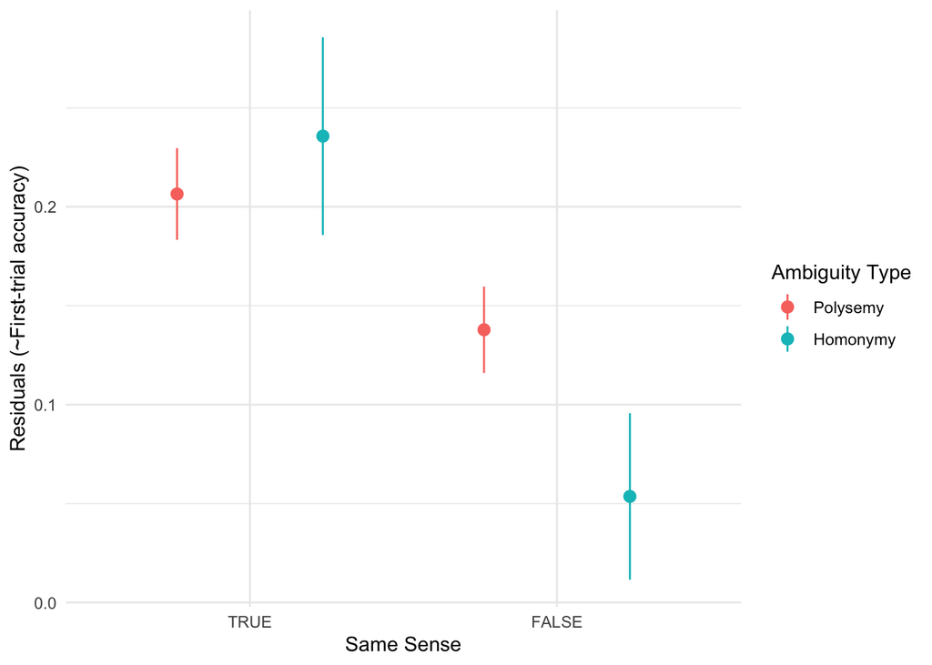

```r
df_merged$residuals = residuals(model_acc_base)

## Residuals ~ Same / Ambiguity Type
df_merged %>%
  ggplot(aes(x = same,
             y = residuals,
             color = ambiguity_type)) +
  stat_summary (fun = function(x){mean(x)},
                fun.min = function(x){mean(x) - 2*sd(x)/sqrt(length(x))},
                fun.max = function(x){mean(x) + 2*sd(x)/sqrt(length(x))},
                geom= 'pointrange',
                position=position_dodge(width=0.95)) +
  labs(x = "Same Sense",
       y = "Residuals (~First-trial accuracy)",
       color = "Ambiguity Type") +
  theme_minimal()
```

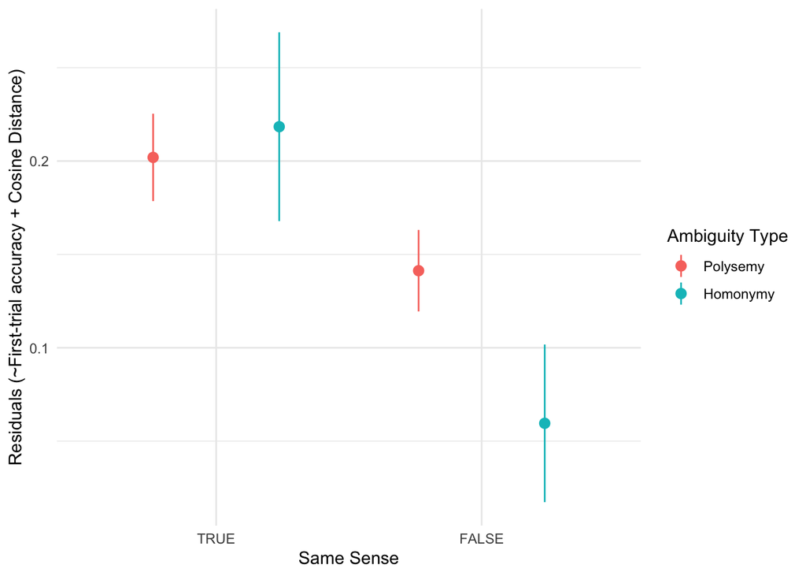

```r
### Also visualize residuals from model with *both* first-trial Accuracy and Cosine Distance
df_merged$residuals2 = residuals(model_distance_acc)

## Residuals ~ Same / Ambiguity Type
df_merged %>%
  ggplot(aes(x = same,
             y = residuals2,
             color = ambiguity_type)) +
  stat_summary (fun = function(x){mean(x)},
                fun.min = function(x){mean(x) - 2*sd(x)/sqrt(length(x))},
                fun.max = function(x){mean(x) + 2*sd(x)/sqrt(length(x))},
                geom= 'pointrange',
                position=position_dodge(width=0.95)) +
  labs(x = "Same Sense",
       y = "Residuals (~First-trial accuracy + Cosine Distance)",
       color = "Ambiguity Type") +
  theme_minimal()
```